# Monitoreo Espacio-Temporal de la variación de los Glaciares Maladeta y Monte Perdido (Pirineos, España): Una Perspectiva Geomática

### **Analizamos la FAS y FAP de la serie original**

Este paso es primordial para escoger el modelo. Se ha realizado la autocorrelación simple y parcial a la serie original (sin diferencias)

En todas las funciones de autocorrelaciones se han elegido 54 lags o retardos ya que tenemos 216 datos y escogiendo ¼ del número de datos como número de retardos

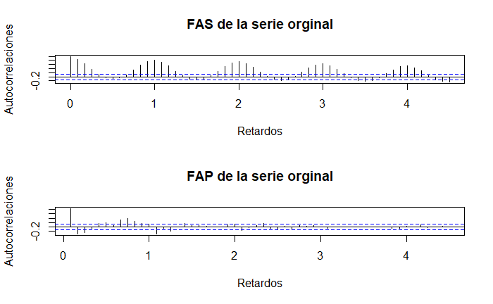

```r
layout(1:2)
acf(temperatura_ts, lag.max=54, ylab="Autocorrelaciones", xlab="Retardos", main="FAS de la serie orginal")
pacf(temperatura_ts, lag.max=54, ylab="Autocorrelaciones", xlab="Retardos", main="FAP de la serie orginal")
```

**Función de Autocorrelación (FAS)**

El eje Y (Autocorrelaciones) representa los valores de autocorrelación para diferentes retardos (lags), mientras que el eje X (Retardos) representa los diferentes retardos (lags) en la serie temporal

Si las barras están dentro de los límites punteados, las autocorrelaciones no son significativamente diferentes de cero.

Podemos decir que decrece lentamente en los primeros retardos y oscila, tiene una forma ondulatoria por lo que no es un proceso ergódico

La disminución gradual de las barras sugiere que la serie tiene memoria, es decir, los valores futuros están correlacionados con los valores pasados, pero esta correlación disminuye con el tiempo.

**Función de Autocorrelación Parcial (FAP)**

El eje Y (Autocorrelaciones) representa los valores de autocorrelación parcial para diferentes retardos.Mientras que el eje X (Retardos) representa los diferentes retardos en la serie temporal.

En este gráfico, se observa que solo las primeras autocorrelaciones parciales son significativas, lo que sugiere que, una vez que se tiene en cuenta la correlación de los valores intermedios, no hay una correlación significativa a largo plazo.

**Transformación de Box‐Cox**

La transformación de potencia, específicamente la transformación de Box-Cox, es una técnica utilizada en análisis de datos y series temporales para estabilizar la varianza, hacer que los datos sigan una distribución más cercana a la normalidad, y mejorar la linealidad entre variables. Esta transformación es útil cuando los datos no cumplen con las suposiciones de homocedasticidad (varianza constante) o normalidad, que son importantes para muchos métodos estadísticos.

En este caso,la serie parece presentar componentes estacionales, con una tendencia creciente en los valores máximos de temperatura, lo que sugiere un calentamiento progresivo.Parece que la magnitud de los picos de temperatura aumenta con el tiempo, lo que sugiere un posible cambio en la varianza. Este es un indicio de que la transformación podría ser útil.

Una manera de evaluar si es necesario es aplicar la transformación de Box-Cox y luego verificar si la varianza se ha estabilizado o si los residuos del modelo tienen una distribución más cercana a la normalidad.

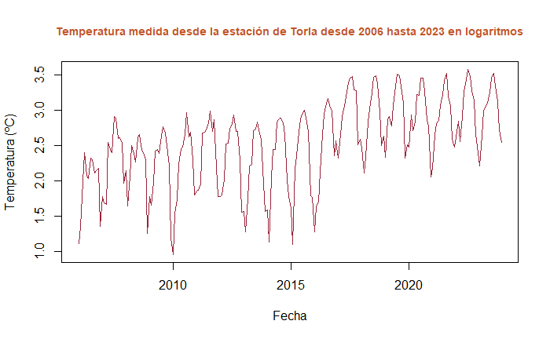

```r
temperatura.log= log(temperatura_ts)#Transformamos mediante logaritmo
plot(temperatura.log, type="l", pch = 19, ylab="Temperatura (ºC)",
xlab="Fecha", main="Temperatura medida desde la estación de Torla desde 2006 hasta 2023 en logaritmos", cex.main = 0.9, col="#992339",  col.main = "#c15628")
```

**Transformación Box-Cox**

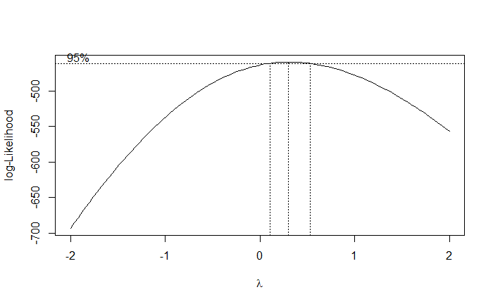

```r
temperatura.bc=boxcox(temperatura_ts~1)
```

```r
str(temperatura.bc)
```

```
List of 2
 $ x: num [1:100] -2 -1.96 -1.92 -1.88 -1.84 ...
 $ y: num [1:100] -693 -686 -678 -671 -663 ...
```

```r
lambda=temperatura.bc$x[which.max(temperatura.bc$y)]

lambda #0.3030303
```

```
[1] 0.3030303
```

La gráfica es el perfil de verosimilitud para la estimación del parámetro λ en una transformación de Box-Cox. El eje vertical representa el valor de la log-verosimilitud, mientras que el eje horizontal muestra diferentes valores de λ. La línea punteada indica el valor máximo de la verosimilitud, que corresponde al valor óptimo de λ, y las líneas adicionales delimitan un intervalo de confianza al 95% para λ

Transformación suave: El valorλ=0.30 indica que los datos probablemente no requieren una transformación muy agresiva para estabilizar la varianza y aproximar una distribución normal. Este valor sugiere que hay cierta heterocedasticidad (cambio en la varianza) en los datos.

Aplicamos la transformación

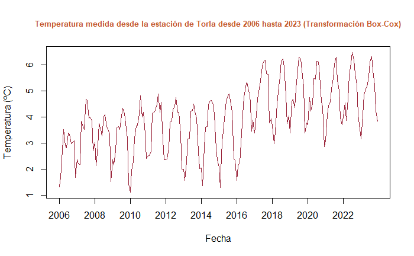

```r
torlatemp.bc= BoxCox(temperatura_ts,lambda)

plot(torlatemp.bc, type="l", pch = 19, ylab="Temperatura (ºC)",
xlab="Fecha", main="Temperatura medida desde la estación de Torla desde 2006 hasta 2023 (Transformación Box-Cox)", cex.main = 0.8, col="#992339",  col.main = "#c15628", xaxt = "n")  # Limitar el eje X a los años deseados y desactivar el eje X por defecto

# Agregar manualmente las etiquetas del eje X
axis(1, at = seq(2006, 2023, by = 2), labels = seq(2006, 2023, by = 2))
```

**Número de diferencias**

El número de diferencias es utilizado para hacer que nuestra serie sea estacionaria, es decir, que no tenga tendencia ni estacionalidad. La presencia de una tendencia y estacionalidad está clara por lo que deberíamos hacer una diferencia regular y una estacional

El test de Dickey-Fuller Aumentado (ADF, por sus siglas en inglés) es una prueba estadística utilizada en análisis de series temporales para determinar si una serie temporal es estacionaria o no. La estacionaridad de una serie temporal es crucial porque muchas técnicas de modelado, como el ARIMA, requieren que las series temporales sean estacionarias para producir resultados válidos.

Raíz Unitaria: El ADF test se centra en verificar la presencia de una raíz unitaria en una serie temporal. Si una serie tiene una raíz unitaria, es no estacionaria, lo que significa que sus propiedades estadísticas (como la media y la varianza) cambian con el tiempo.

Modelo Autorregresivo (AR): El test de Dickey-Fuller básico se basa en un modelo autorregresivo de primer orden. La versión mejorada (ADF) extiende esto para considerar posibles autocorrelaciones de mayor orden en los errores del modelo.